# Project 1 based on Angrist and Krueger (1991, QJE)

Damien LEVACHER, Théo COSTANZO, Zeinabou AMADOU HAINIKOYE

2025-01-24

# Project 1

In this Project we will try and replicate the different graphs and tables

## I.Preliminaries

```r
library(tidyverse) #we will be using tidyverse to be able to graph using ggplot
library(here)
library(lubridate)
library(gridExtra)
library(stargazer) #stargazer will be used in Question 2 to export tables
library(AER)        ## for ivreg, this will be used to make the IVregressions
library(ipumsr)     ##for extracting ipums data
library(dplyr)
library(kableExtra)  ##to make tables
```

We used the code written in the instructions of the project to be able to set the correct data base named pums.

```r
pums <- read.table(paste("QOB.raw",sep=""),
                   header           = FALSE,
                   stringsAsFactors = FALSE)
colnames(pums)[c(1,2,4,5,6,9:13,16,18,19:21,24,25,27)] <- c("AGE", "AGEQ", "EDUC",
                                                            "ENOCENT","ESOCENT", "LWKLYWGE",
                                                            "MARRIED", "MIDATL", "MT", "NEWENG", "CENSUS", "QOB", "RACE",
                                                            "SMSA", "SOATL", "WNOCENT", "WSOCENT", "YOB")
pums <- as_tibble(pums)

pums %>%
  mutate(cohort = factor(1*(YOB<=39 & YOB >=30) +
                           2*(YOB<=49 & YOB >=40),
                         levels=c(1,2), labels=c("30-39","40-49")) ) -> pums

ymd(paste("19",30,4 * 3, sep=""),truncated = 2)
```

```
## [1] "1930-12-01"
```

```r
pums <- as_tibble(pums)
```

## II.Question 1

Explain the research design of the paper (1). In particular, explain why estimation by OLS is likely to be invalid (2), explain the nature of the instruments (3), and discuss whether the proposed instrumental variable strategy is credible. (4)

1. The research design of the paper is to determine the causal relationship between education and earnings using instrumental variable. The reason of this choice is due to fix some endogeneity problems in ordinary least squares regression.
2. OLS estimates may be biased and inconsistent due to endogeneity issues:
- Some omitted factors like motivation might affect both education and earnings. That’s the main reason why correlation doesn’t imply causality. (omitted variables)
- Higher earnings may also get individuals to continue more years of studying. (reverse effect)
- Errors in measuring years of schooling make some bias in OLS estimates. (errors measurement)
3. The authors use ‘quarter of birth’ as an instrumental variable for years of schooling. The authors suggest that individuals may have different levels of schooling because of the timing of attending class according the months of their birth and when they leave school.
4. 2 factors can contribute to the credibility of the instrumental variable strategy.
- First, the instrument must be correlated with the endogenous variable (education).
- Secondly the instrument must not be directly related to the outcome variable (earnings), only via its effect on education.

## III.1.1 Question 2

**In this Question we have been tasked to replicate the graph 1 which is a graph showing the evolution between the Year of Birth and their Educational Levels, and we will have to graph the graph 5 which is the evolution between the Year of Birth and the wage (in log average earnings).**

*These are the steps to be able to replicate the graphs :*

**Step 1** : Changing the date format so that we can have clearer values to show in the graph.

```r
pums <- pums %>%
  mutate(YOB = as.Date(paste("19", YOB, "01-02", sep = ""), format = "%Y%d-%m"))
```

**Step 2** : We then calculate the average of EDUC and LWKLYWGE to have one point per year of birth.

```r
educ_mean <- pums %>%
  group_by(YOB, QOB) %>%
  summarise(mean_EDUC = mean(EDUC),
            mean_LWKLYWGE = mean(LWKLYWGE),
            .groups = 'keep')
```

**Step 3** : Creation of a variable associating year and quarter of birth

```r
educ_mean <- educ_mean %>%
  mutate(YQOB = paste(YOB, QOB, sep = "-"))
```

**Step 4** : We plot the first figure into the object p1

```r
#Creation of 2 graphics
p1 <-ggplot(educ_mean, aes(x = YQOB, y = mean_EDUC, label = as.character(QOB), color = as.character(QOB))) +
  geom_point(size = 3, shape = 16) +
  geom_line(aes(group = 1), color = "black") +
  geom_text(aes(label = QOB), color = "white", size = 2) +
  scale_color_manual(values = c("1" = "red", "2" = "black", "3" = "black", "4" = "black"), guide = "none") +
  labs(x = "Year of birth", y = "Years of completed education", title = "Figure 1 : Average education by quarter of birth") +
  scale_x_discrete(breaks = c("1930-02-01-1","1935-02-01-1", "1940-02-01-1",
                              "1945-02-01-1", "1949-02-01-4"),
                   labels = c("1930-02-01-1" = "1930","1935-02-01-1" ="1935",
                              "1940-02-01-1" = "1940","1945-02-01-1" = "1945",
                              "1949-02-01-4" = "1950"))
```

**Step 5** : We then plot the second figure into the object p2

```r
p2 <-ggplot(educ_mean, aes(x = YQOB, y = mean_LWKLYWGE, label = as.character(QOB), color = as.character(QOB))) +
  geom_point(size = 3, shape = 16) +
  geom_line(aes(group = 1), color = "black") +
  geom_text(aes(label = QOB), color = "white", size = 2) +
  scale_color_manual(values = c("1" = "red", "2" = "black", "3" = "black", "4" = "black"), guide = "none") +
  labs(x = "Year of birth", y = "Log weekly earnings", title = "Figure 2 : Average weekly wage by quarter of birth") +
  scale_x_discrete(breaks = c("1930-02-01-1","1935-02-01-1",
                              "1940-02-01-1","1945-02-01-1", "1949-02-01-4"),
                   labels = c("1930-02-01-1" = "1930","1935-02-01-1" ="1935",
                              "1940-02-01-1" = "1940","1945-02-01-1" = "1945",
                              "1949-02-01-4" = "1950"))
```

### III.1.2 Figure 1

**We then View our graphs.**

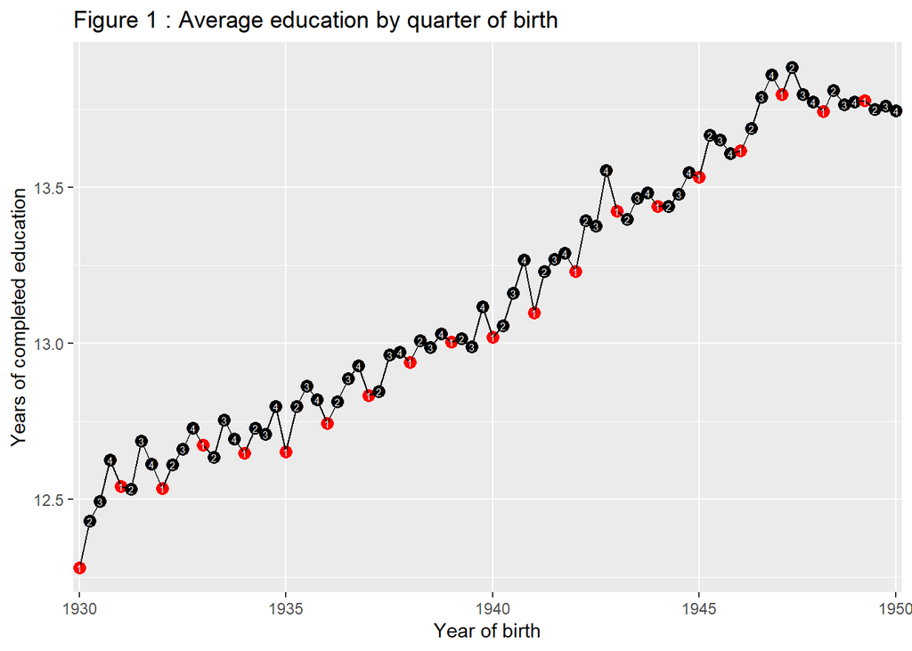

```r
p1
```

### III.1.3 Figure 2

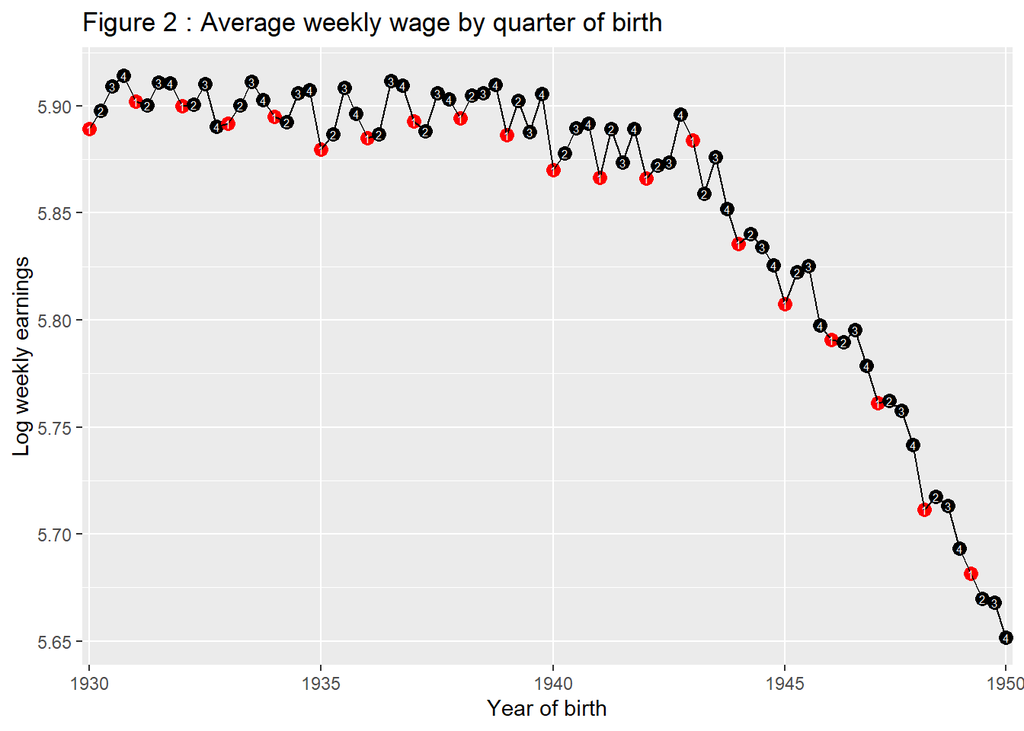

```r
p2
```

### III.1.4 Wald Estimator

```r
pums %>%
    filter(cohort == "30-39") -> pums.tab5

pums.tab5$wald_dum <- (pums.tab5$QOB == 3 | pums.tab5$QOB == 4) * 1
```

*The following code is the method to extract the Wald Estimator:*

**Step 1** : Mutating pums.tab5 to define the variable wald_dum

```r
pums.tab5 <- pums.tab5 %>%
  mutate(wald_dum = as.numeric(QOB == 2 | QOB == 3 | QOB == 4))
```

**Step 2** : Calculate the means for the groups

```r
mean_ln_wage_q1 <- mean(pums.tab5$LWKLYWGE[pums.tab5$QOB == 1], na.rm = TRUE)
mean_ln_wage_q2_4 <- mean(pums.tab5$LWKLYWGE[pums.tab5$wald_dum == 1], na.rm = TRUE)
mean_education_q1 <- mean(pums.tab5$EDUC[pums.tab5$QOB == 1], na.rm = TRUE)
mean_education_q2_4 <- mean(pums.tab5$EDUC[pums.tab5$wald_dum == 1], na.rm = TRUE)
```

**Step 3** : Calculate the Wald estimator

```r
wald_estimator <- (mean_ln_wage_q1 - mean_ln_wage_q2_4) / (mean_education_q1 - mean_education_q2_4)
```

**Step 4** : Calculate the group sizes

```r
n_q1 <- sum(!is.na(pums.tab5$LWKLYWGE[pums.tab5$QOB == 1]))
n_q2_4 <- sum(!is.na(pums.tab5$LWKLYWGE[pums.tab5$wald_dum == 1]))
```

**Step 5** : Calculate the variances

```r
var_ln_wage_q1 <- var(pums.tab5$LWKLYWGE[pums.tab5$QOB == 1], na.rm = TRUE)
var_ln_wage_q2_4 <- var(pums.tab5$LWKLYWGE[pums.tab5$wald_dum == 1], na.rm = TRUE)
var_education_q1 <- var(pums.tab5$EDUC[pums.tab5$QOB == 1], na.rm = TRUE)
var_education_q2_4 <- var(pums.tab5$EDUC[pums.tab5$wald_dum == 1], na.rm = TRUE)
```

**Step 6** : Calculate the standard errors for the differences

```r
se_ln_wage_diff <- sqrt(var_ln_wage_q1 / n_q1 + var_ln_wage_q2_4 / n_q2_4)
se_education_diff <- sqrt(var_education_q1 / n_q1 + var_education_q2_4 / n_q2_4)
```

**Step 7** : Calculate the standard error for the Wald estimator

```r
wald_se <- sqrt(
  (se_ln_wage_diff^2 / (mean_education_q1 - mean_education_q2_4)^2) +
    ((mean_ln_wage_q1 - mean_ln_wage_q2_4)^2 * se_education_diff^2 / (mean_education_q1 - mean_education_q2_4)^4)
)
```

**Step 8** : Adjust the OLS regression for the return to education

```r
reg_ols <- lm(LWKLYWGE ~ EDUC, data = pums.tab5)
```

**Step 9** : Retrieve the OLS results

```r
ols_return <- coef(reg_ols)["EDUC"]
ols_se <- summary(reg_ols)$coefficients["EDUC", 2]
```

**Step 10** : Create the results table with standard errors

```r
data3 <- data.frame(
  ln_wkly_wage = c(
    round(mean_ln_wage_q1, 5),
    round(mean_ln_wage_q2_4, 5),
    paste0(round(mean_ln_wage_q1 - mean_ln_wage_q2_4, 5), " (", round(se_ln_wage_diff, 5), ")")
  ),
  Education = c(
    round(mean_education_q1, 4),
    round(mean_education_q2_4, 4),
    paste0(round(mean_education_q1 - mean_education_q2_4, 4), " (", round(se_education_diff, 4), ")")
  ),
  Wald_estimator = c(
    "", "",
    paste0(round(wald_estimator, 4), " (", round(wald_se, 4), ")")
  ),
  OLS_return_of_education = c(
    "", "",
    paste0(round(ols_return, 4), " (", round(ols_se, 4), ")")
  ),
  row.names = c(
    "Born in 1st quarter of year",
    "Born in 2nd, 3rd or 4th quarter of year",
    "Difference (std. error) (1)-(2)"
  )
)

# Transpose the data for flipping
data3_flipped <- as.data.frame(t(data3))

# Fix row and column names for better readability
rownames(data3_flipped) <- c(
  "ln (wky. wage)",
  "Education",
  "Wald est. of return to education",
  "OLS return to education"
)
colnames(data3_flipped) <- c("(1)", "(2)", "(3)")

# Generate the flipped table
t1 <- kable(data3_flipped, format = "html", escape = FALSE) %>%
  kable_styling(full_width = FALSE, bootstrap_options = c("striped", "hover")) %>%
  add_header_above(c(" " = 1, "Born in 1st quarter of year" = 1, "Born in 2nd, 3rd, or 4th quarter of year" = 1, "Difference (std. error)" = 1))

t1
```

Born in 1st quarter of year

Born in 2nd, 3rd, or 4th quarter of year

Difference (std. error)

ln (wky. wage)

5.8916

5.90269

-0.0111 (0.00274)

Education

12.6881

12.7969

-0.1088 (0.0133)

Wald est. of return to education

0.102 (0.0281)

OLS return to education

0.0709 (3e-04)

The table shows that men born in the 1st quarter have slightly less education (-0.11 years) and lower earnings (-1.1%) than those born later. The Wald estimate of returns to education is 10.2%, higher than the OLS estimate 7.1%), indicating higher returns when accounting for biases.

### III.1.5 Table 5 (OLS and IV)

We will be doing the code of Table 5 which implies to make regression models.

**Step 1** : We mutate pums for years from 1930 to 1939 and turn it into pums.tab5

```r
pums %>%
  filter(cohort == "30-39") -> pums.tab5
```

**Step 2**: We create the region variable by combining the regional variables

```r
pums.tab5 %>%
  mutate(region = as.factor(paste(NEWENG, MIDATL, ENOCENT, WNOCENT, SOATL, ESOCENT, WSOCENT, MT, sep = "_"))) -> pums.tab6
```

**Step 3**: We create the YOB_factor for Year of Birth fixed effects

```r
pums.tab6 %>%
  mutate(YOB_factor = as.factor(YOB)) -> pums.tab6
```

**Step 4**: Then we create the OLS Regressions

```r
reg1 = lm(LWKLYWGE ~ EDUC + YOB_factor, data = pums.tab6)
reg3 = lm(LWKLYWGE ~ EDUC + YOB_factor + AGE + I(AGE^2),pums.tab6)
reg5 = lm(LWKLYWGE ~ EDUC + factor(RACE) + factor(SMSA) + factor(MARRIED) + YOB_factor + region, data = pums.tab6)
reg7 = lm(LWKLYWGE ~ EDUC + factor(RACE) + factor(SMSA) + factor(MARRIED) + YOB_factor + AGE + I(AGE^2) + region, data = pums.tab6)

is_dummy_included <- function(model, variables) {
  included_vars <- names(coef(model))
  any(grepl(paste(variables, collapse = "|"), included_vars))
}
```

**Step 5** : Dummy Variables for Detection

```r
year_dummies <- paste0("YOB_factor", levels(pums.tab6$YOB_factor))
region_dummies <- levels(pums.tab6$region)
```

**Step 6** : Yes/No Helper Function

```r
yes_no <- function(logical_value) {
  if (logical_value) "Yes" else "No"
}
```

**Step 7**: Dynamic Add Lines

```r
ols_year_dummies <- sapply(list(reg1, reg3, reg5, reg7), function(model) is_dummy_included(model, year_dummies))
ols_region_dummies <- sapply(list(reg1, reg3, reg5, reg7), function(model) is_dummy_included(model, region_dummies))
```

**Step 8**: Creating the OLS Summary Table

```r
stargazer(
  reg1, reg3,reg5, reg7,
  dep.var.caption = "",
  dep.var.labels = "",
  omit = c("YOB_factor", "region", "Constant"), # omit the fixed effects for year of birth and region
  add.lines = list(
    c("9 Year-of-birth dummies", sapply(ols_year_dummies, yes_no)),
    c("8 Region-of-residence dummies", sapply(ols_region_dummies, yes_no))
  ),
  star.cutoffs = NA,
  keep.stat = c("n", "rsq"),
  no.space = TRUE,
  header = FALSE,
  column.labels = c("OLS", "OLS", "OLS","OLS"),
  title = "OLS Estimation of the Return to Education for Men Born 1930-1939: 1980 Census",
  type = "text"
)
```

```
##
## OLS Estimation of the Return to Education for Men Born 1930-1939: 1980 Census
## =================================================================
##
##                                 OLS      OLS      OLS      OLS
##                                 (1)      (2)      (3)      (4)
## -----------------------------------------------------------------
## EDUC                           0.071    0.071    0.063    0.063
##                               (0.0003) (0.0003) (0.0003) (0.0003)
## factor(RACE)1                                    -0.257   -0.257
##                                                 (0.004)  (0.004)
## factor(SMSA)1                                    -0.176   -0.176
##                                                 (0.003)  (0.003)
## factor(MARRIED)1                                 0.248    0.248
##                                                 (0.003)  (0.003)
## AGE                                     -0.048            -0.042
##                                        (0.040)           (0.039)
## I(AGE2)                                 0.0005            0.0004
##                                        (0.0004)          (0.0004)
## -----------------------------------------------------------------
## 9 Year-of-birth dummies         Yes      Yes      Yes      Yes
## 8 Region-of-residence dummies    No       No      Yes      Yes
## Observations                  329,509  329,509  329,509  329,509
## R2                             0.118    0.118    0.165    0.165
## =================================================================
## Note:                                                          NA
```

**Step 9**: Creating QOB_Year Interaction

```r
pums.tab6 <- pums.tab6 %>%
  mutate(QOB_Year = paste(QOB, YOB, sep = "_"))
```

**Step 10**: TSLS Regressions (Instrumental Variable Regressions)

```r
reg_IV2 <- ivreg(LWKLYWGE ~ EDUC + YOB_factor | QOB_Year + YOB_factor, data = pums.tab6)
reg_IV4 <- ivreg(LWKLYWGE ~ EDUC  + YOB_factor + AGE +  I(AGE^2)  |
                   QOB_Year  + YOB_factor+ AGE +  I(AGE^2), data = pums.tab6)
reg_IV6 <- ivreg(LWKLYWGE ~ EDUC + factor(RACE) + factor(SMSA) + factor(MARRIED) + YOB_factor + region | QOB_Year + factor(RACE) + factor(SMSA) + factor(MARRIED) + YOB_factor + region, data = pums.tab6)
reg_IV8 <- ivreg(LWKLYWGE ~ EDUC + factor(RACE) + factor(SMSA) + factor(MARRIED) + YOB_factor + AGE +  I(AGE^2) + region | QOB_Year + factor(RACE) + factor(SMSA) + factor(MARRIED) + YOB_factor + region, data = pums.tab6)

tsls_year_dummies <- sapply(list(reg_IV2, reg_IV4, reg_IV6, reg_IV8), function(model) is_dummy_included(model, year_dummies))
tsls_region_dummies <- sapply(list(reg_IV2, reg_IV4, reg_IV6, reg_IV8), function(model) is_dummy_included(model, region_dummies))
```

**Step 11** : Calculating the statistics $\chi^2$

```r
compute_chisq <- function(reg_full, reg_restricted) {
  # Calculating of the Residues
  rss_full <- sum(resid(reg_full)^2)
  rss_restricted <- sum(resid(reg_restricted)^2)

  # Calculation of the degrees of freedom
  df_full <- length(coef(reg_full)) - 1  # get rid of the intercept
  df_restricted <- length(coef(reg_restricted)) - 1

  # Formula for \( \chi^2 \)
  chisq_stat <- (rss_restricted - rss_full) / rss_full * df_full

  # Return \( \chi^2 \) and the degrees of freedom
  return(list(chisq = chisq_stat, df = df_full - df_restricted))
}

# Restraints models for each Tsls
restricted_reg_IV2 <- lm(LWKLYWGE ~ 1, data = pums.tab6)  # Nul Model
restricted_reg_IV4 <- lm(LWKLYWGE ~ 1, data = pums.tab6)
restricted_reg_IV6 <- lm(LWKLYWGE ~ 1, data = pums.tab6)
restricted_reg_IV8 <- lm(LWKLYWGE ~ 1, data = pums.tab6)

# Calculation of the\( \chi^2 \)
chisq_IV2 <- compute_chisq(reg_IV2, restricted_reg_IV2)
chisq_IV4 <- compute_chisq(reg_IV4, restricted_reg_IV4)
chisq_IV6 <- compute_chisq(reg_IV6, restricted_reg_IV6)
chisq_IV8 <- compute_chisq(reg_IV8, restricted_reg_IV8)
```

**Step 12** : TSLS table

```r
stargazer(
  reg_IV2, reg_IV4,  reg_IV6, reg_IV8,
  dep.var.caption = "",
  dep.var.labels = "",
  omit = c("YOB_factor", "region", "Constant"),
  add.lines = list(
    c("9 Year-of-birth dummies", sapply(tsls_year_dummies, yes_no)),
    c("8 Region-of-residence dummies", sapply(tsls_region_dummies, yes_no)),
    c("\u03C7\u00B2 (dof)",              # Row for \( \chi^2 \)
      paste0(round(chisq_IV2$chisq, 2), " [", chisq_IV2$df, "]"), # TSLS Column 2
      paste0(round(chisq_IV4$chisq, 2), " [", chisq_IV4$df, "]"), # TSLS Column 4
      paste0(round(chisq_IV6$chisq, 2), " [", chisq_IV6$df, "]"), # TSLS Column 6
      paste0(round(chisq_IV8$chisq, 2), " [", chisq_IV8$df, "]")  # TSLS Column 8
    )
  ),
  star.cutoffs = NA,
  keep.stat = c("n", "rsq"), # show only n and R2
  no.space = TRUE,
  header = FALSE,
  column.labels = c("TSLS", "TSLS", "TSLS", "TSLS"),
  title = " TSLS ESTIMATES OF THE RETURN TO EDUCATION FOR MEN BORN 1930-1939: 1980 CENSUS",
  type = "text",
  covariate.labels = c(
    "Years of education",
    "Race (1 = Black)",
    "SMSA (1 = center city)",
    "Married (1 = married)",
    "Age",
    "Age-squared"
  ),
  digits = 4
)
```

```
##
## TSLS ESTIMATES OF THE RETURN TO EDUCATION FOR MEN BORN 1930-1939: 1980 CENSUS
## =====================================================================
##
##                                 TSLS      TSLS      TSLS      TSLS
##                                  (1)       (2)       (3)       (4)
## ---------------------------------------------------------------------
## Years of education             0.0891    0.0832    0.0806    0.0766
##                               (0.0161)  (0.0221)  (0.0164)  (0.0219)
## Race (1 = Black)                                   -0.2302   -0.2364
##                                                   (0.0261)  (0.0348)
## SMSA (1 = center city)                             -0.1581   -0.1622
##                                                   (0.0174)  (0.0232)
## Married (1 = married)                              0.2440    0.2449
##                                                   (0.0049)  (0.0059)
## Age                                      -0.0517             -0.0467
##                                         (0.0407)            (0.0396)
## Age-squared                              0.0005              0.0005
##                                         (0.0005)            (0.0004)
## ---------------------------------------------------------------------
## 9 Year-of-birth dummies          Yes       Yes       Yes       Yes
## 8 Region-of-residence dummies    No        No        Yes       Yes
## χ² (dof)                      1.24 [10] 1.55 [12] 3.95 [21] 4.42 [23]
## Observations                   329,509   329,509   329,509   329,509
## R2                             0.1102    0.1143    0.1584    0.1611
## =====================================================================
## Note:                                                              NA
```

**Step 13** : Making the combined table with the ols regressions and the Tsls

```r
stargazer(
  reg1, reg_IV2, reg3, reg_IV4, reg5, reg_IV6, reg7, reg_IV8,
  dep.var.caption = "",
  dep.var.labels = "",
  omit = c("YOB_factor", "region", "Constant"),
  add.lines = list(
    c("9 Year-of-birth dummies",
      yes_no(ols_year_dummies[1]), yes_no(tsls_year_dummies[1]),
      yes_no(ols_year_dummies[2]), yes_no(tsls_year_dummies[2]),
      yes_no(ols_year_dummies[3]), yes_no(tsls_year_dummies[3]),
      yes_no(ols_year_dummies[4]), yes_no(tsls_year_dummies[4])
    ),
    c("8 Region-of-residence dummies",
      yes_no(ols_region_dummies[1]), yes_no(tsls_region_dummies[1]),
      yes_no(ols_region_dummies[2]), yes_no(tsls_region_dummies[2]),
      yes_no(ols_region_dummies[3]), yes_no(tsls_region_dummies[3]),
      yes_no(ols_region_dummies[4]), yes_no(tsls_region_dummies[4])
    ),
    c("\u03C7\u00B2 (dof)",              # Lines for \( \chi^2 \)
      "",                               # OLS Column (empty for \( \chi^2 \))
      paste0(round(chisq_IV2$chisq, 2), " [", chisq_IV2$df, "]"), # TSLS column 2
      "",                               # OLS Column (empty for \( \chi^2 \))
      paste0(round(chisq_IV4$chisq, 2), " [", chisq_IV4$df, "]"), # TSLS column 4
      "",                               # OLS Column (empty for \( \chi^2 \))
      paste0(round(chisq_IV6$chisq, 2), " [", chisq_IV6$df, "]"), # TSLS column 6
      "",                               # OLS Column (empty for \( \chi^2 \))
      paste0(round(chisq_IV8$chisq, 2), " [", chisq_IV8$df, "]")  # TSLS column 8
    )
  ),
  star.cutoffs = NA,
  keep.stat = c("n", "rsq"), # Show only n and R^2
  no.space = TRUE,
  header = TRUE,
  column.labels = c("OLS", "TSLS", "OLS", "TSLS", "OLS", "TSLS", "OLS", "TSLS"),
  title = "OLS AND TSLS ESTIMATES OF THE RETURN TO EDUCATION FOR MEN BORN 1930-1939: 1980 CENSUS",
  type = "text",
  covariate.labels = c(
    "Years of education",
    "Race (1 = Black)",
    "SMSA (1 = center city)",
    "Married (1 = married)",
    "Age",
    "Age-squared"
  ),
  digits = 4
)
```

```
##
## OLS AND TSLS ESTIMATES OF THE RETURN TO EDUCATION FOR MEN BORN 1930-1939: 1980 CENSUS
## =====================================================================================================================
##
##                                 OLS    instrumental   OLS    instrumental   OLS    instrumental   OLS    instrumental
##                                          variable              variable              variable              variable
##                                 OLS        TSLS       OLS        TSLS       OLS        TSLS       OLS        TSLS
##                                 (1)        (2)        (3)        (4)        (5)        (6)        (7)        (8)
## ---------------------------------------------------------------------------------------------------------------------
## Years of education             0.0711     0.0891     0.0711     0.0832     0.0632     0.0806     0.0632     0.0766
##                               (0.0003)   (0.0161)   (0.0003)   (0.0221)   (0.0003)   (0.0164)   (0.0003)   (0.0219)
## Race (1 = Black)                                                          -0.2575    -0.2302    -0.2575    -0.2364
##                                                                           (0.0040)   (0.0261)   (0.0040)   (0.0348)
## SMSA (1 = center city)                                                    -0.1763    -0.1581    -0.1763    -0.1622
##                                                                           (0.0029)   (0.0174)   (0.0029)   (0.0232)
## Married (1 = married)                                                      0.2479     0.2440     0.2479     0.2449
##                                                                           (0.0032)   (0.0049)   (0.0032)   (0.0059)
## Age                                                 -0.0475    -0.0517                          -0.0421    -0.0467
##                                                     (0.0399)   (0.0407)                         (0.0388)   (0.0396)
## Age-squared                                          0.0005     0.0005                           0.0004     0.0005
##                                                     (0.0004)   (0.0005)                         (0.0004)   (0.0004)
## ---------------------------------------------------------------------------------------------------------------------
## 9 Year-of-birth dummies         Yes        Yes        Yes        Yes        Yes        Yes        Yes        Yes
## 8 Region-of-residence dummies    No         No         No         No        Yes        Yes        Yes        Yes
## χ² (dof)                                1.24 [10]             1.55 [12]             3.95 [21]             4.42 [23]
## Observations                  329,509    329,509    329,509    329,509    329,509    329,509    329,509    329,509
## R2                             0.1177     0.1102     0.1178     0.1143     0.1650     0.1584     0.1650     0.1611
## =====================================================================================================================
## Note:                                                                                                              NA
```

In the tables, we do not have the correct values for the khi². This may be due to not having the same data base. If we had the original data base we may be able to extract the same values needed for the khi².

The table shows OLS and TSLS estimates of returns to education using 1980 Census data. OLS estimates a 7.1% increase in earnings per year of education, while TSLS suggests a higher return 8.9% but with more variability. More variables (like race, marital status) show significant effects on earnings. TSLS addresses potential bias but has larger standard errors, questioning instrument reliability.

## IV.Question 3

To be able to extract ipums US 1980 we need to use the code used in Homework 5. We must extract the necessary variables to replicate what we did in Question 2 which are Birth year, level of education, race, birth quarter, and income wage :

```
# the ACS 1980 has id: us1980d
usa_ext_def <- define_extract_usa(
  description = "Extract for individuals born between 1930 and 1939",
  samples = c("us1980a"),
  variables = c("BIRTHYR", "EDUC", "AGE", "RACE", "BIRTHQTR", "INCWAGE")
)

usa_ext_submitted <- submit_extract(usa_ext_def)

usa_ext_complete <- wait_for_extract(usa_ext_submitted)

filepath <- download_extract(usa_ext_submitted,
                             download_dir = "~")

ddi <- read_ipums_ddi(filepath)
dat1980 <- read_ipums_micro(ddi)

# Convert column names to lowercase
colnames(dat1980) <- str_to_lower(colnames(dat1980))
```

To compare the QQB.raw data from the 1980census Ipums a good way to look is by looking at the same graph to compare them side by side. We are only interested from the individuals born from 1930 to 1950. We will be doing the same steps in the Question 2 to view p1 and p2. This is the following code :

```r
dat1980_clean <- dat1980 %>%
  select(birthyr, educ, age, race, birthqtr, incwage)%>%
  filter(birthyr > 1930 & birthyr < 1950)%>%
  mutate(ln_incwage = ifelse(incwage == 0, 0, log(incwage)))

# Glimpse the filtered data
glimpse(dat1980_clean)
```

```
## Rows: 2,578,544
## Columns: 7
## $ birthyr    <dbl+lbl> 1934, 1948, 1932, 1945, 1941, 1948, 1947, 1937, 1935, 1…
## $ educ       <int+lbl> 6, 6, 6, 6, 6, 11, 11, 11, 8, 6, 10, 9, 6, 8, 7, 6, 8, …
## $ age        <int+lbl> 45, 32, 47, 34, 38, 31, 33, 42, 45, 41, 37, 40, 43, 31,…
## $ race       <int+lbl> 1, 7, 1, 1, 1, 1, 1, 1, 1, 1, 1, 1, 1, 1, 1, 1, 1, 1, 1…
## $ birthqtr   <int+lbl> 4, 1, 3, 3, 4, 2, 1, 2, 1, 2, 1, 1, 3, 1, 1, 4, 4, 3, 1…
## $ incwage    <dbl+lbl>   205,     0, 27605, 20135,     0, 20005, 27005, 30005,…
## $ ln_incwage <dbl> 5.323010, 0.000000, 10.225752, 9.910215, 0.000000, 9.903738…
```

```r
educ_mean <- dat1980_clean %>%
  group_by(birthyr, birthqtr) %>%
  summarise(mean_EDUC = mean(educ),
            mean_LWKLYWGE = mean(incwage),
            .groups = 'keep')

#Sort by year of birth
educ_mean <- educ_mean[order(educ_mean$birthyr), ]

#Creation of a variable associating year and quarter of birth
# Updated to include proper YQOB formatting
educ_mean <- educ_mean %>%
  mutate(YQOB = paste(birthyr, birthqtr, sep = "-Q"))  # Update format to YYYY-Q

# Updated graphics with corrected x-axis values
p3 <- ggplot(educ_mean, aes(x = YQOB, y = mean_EDUC, label = as.character(birthqtr), color = as.character(birthqtr))) +
  geom_point(size = 3, shape = 16) +
  geom_line(aes(group = 1), color = "black") +
  geom_text(aes(label = birthqtr), color = "white", size = 2) +
  scale_color_manual(values = c("1" = "red", "2" = "black", "3" = "black", "4" = "black"), guide = "none") +
  labs(x = "Year of birth", y = "Years of completed education", title = "Figure 1 : Average education by quarter of birth(ipumsr)") +
  scale_x_discrete(breaks = c("1930-Q1", "1935-Q1", "1940-Q1", "1945-Q1", "1949-Q4"),
                   labels = c("1930-Q1" = "1930", "1935-Q1" = "1935", "1940-Q1" = "1940", "1945-Q1" = "1945", "1949-Q4" = "1950"))

p4 <- ggplot(educ_mean, aes(x = YQOB, y = mean_LWKLYWGE, label = as.character(birthqtr), color = as.character(birthqtr))) +
  geom_point(size = 3, shape = 16) +
  geom_line(aes(group = 1), color = "black") +
  geom_text(aes(label = birthqtr), color = "white", size = 2) +
  scale_color_manual(values = c("1" = "red", "2" = "black", "3" = "black", "4" = "black"), guide = "none") +
  labs(x = "Year of birth", y = "Weekly earnings", title = "Figure 2 : Average weekly wage by quarter of birth(ipumsr)") +
  scale_x_discrete(breaks = c("1930-Q1", "1935-Q1", "1940-Q1", "1945-Q1", "1949-Q4"),
                   labels = c("1930-Q1" = "1930", "1935-Q1" = "1935", "1940-Q1" = "1940", "1945-Q1" = "1945", "1949-Q4" = "1950"))
```

### IV.1 Difference in the relationship between Year of Birth and Level of education

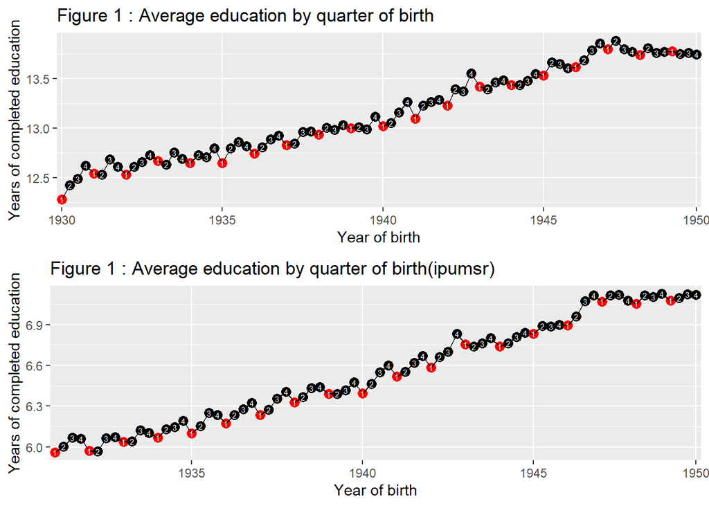

```r
grid.arrange(p1, p3, nrow = 2)
```

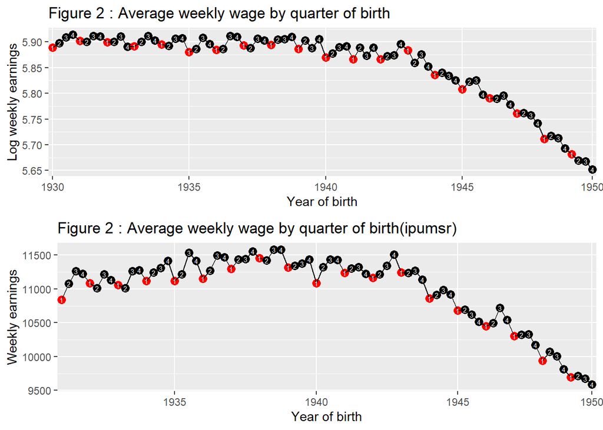

```r
grid.arrange(p2, p4, nrow = 2)
```

Now as we see in the first graph the beginning of the years so from 1930 to 1939 we have a constant correlation with the log of weekly wage income and the year of birth. However in the second graph instead of seeing no growth we see a growth, making us understand that the first decade’s average income has been increasing. This could also strengthen the theory in the first contrast between the first figure that the data collected from IPUMS1980 is more accurate.